# Análise de Criminalidade no Estado de São Paulo (2016-2025)

## Tendência para crimes contra a Pessoa

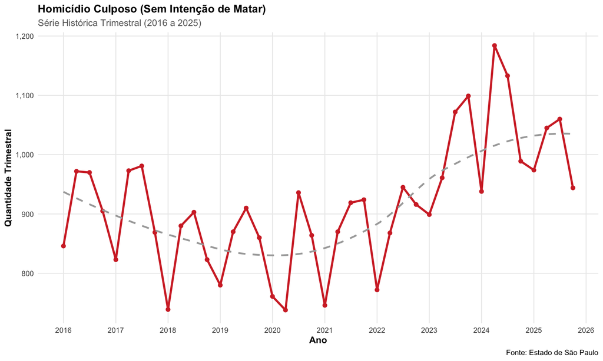

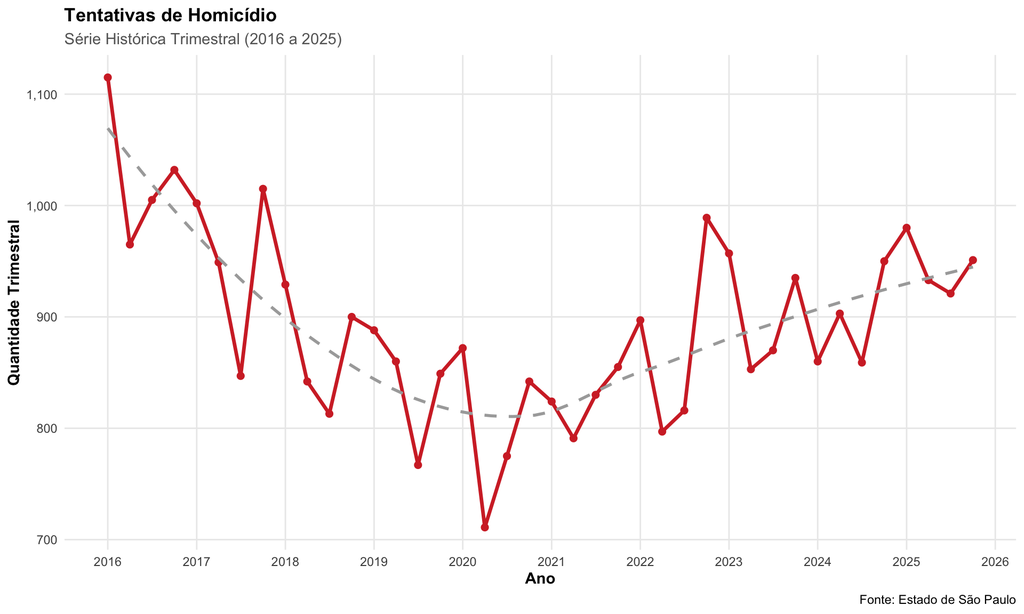

A análise específica dos **Crimes contra a Pessoa**, abordando mortes culposas e atentas à vida que não se consumaram, traz um contraponto importante sobre qual perfil de violência está crescendo verdadeiramente no Estado de São Paulo:

1. **Aumento Consistente dos Homicídios Culposos:** Observamos uma tendência consolidada de alta nos homicídios culposos (onde não há intenção primária de matar, estando frequentemente associados a fatalidades sistêmicas, violência no trânsito ou negligência imprudente). A série apresentava uma média contida em cerca de **882 casos** por trimestre antes da pandemia; porém, a curva cresceu de forma contínua a ponto de cruzar, repetidas vezes, a barreira de mais de **1.000 mortes/trimestre** a partir de 2023. Isso compõe um aumento sistemático e não-ignível de **+16,3%**.
2. **Estabilidade Absoluta nas Tentativas de Homicídio:** Em contrapartida nítida, as *Tentativas de Homicídio* (crimes violentos, agressões diretas com dolo de matar, mas interceptadas) não pioraram estruturalmente. A sua média pré-crise orbitava na casa de 924 registros trimestrais, oscilando para exatos **914 casos/trimestre** no período recente pós-2022. Essa é uma variação achatada de essencialmente **-1,0%** (estabilidade perfeita).

A união destes dois cenários endossa a lógica discutida na tendência geral: ao cruzar a não-piora da intenção ativa de matar de um lado e o salto formidável em vítimas letais de homicídios culposos do outro, concluímos que a violência clássica e premeditada das ruas paulistas não avançou massivamente — o perigo e as fatalidades estruturais cresceram através de vias mais imprudentes/acidentais dentro da sociedade ou tráfego civil.